# **Análise Geoespacial e Mapa Interativo**

## **Mobilidade dos Táxis de Nova Iorque**

#### Autor: Luis Rito Filipe

#### Maio de 2025

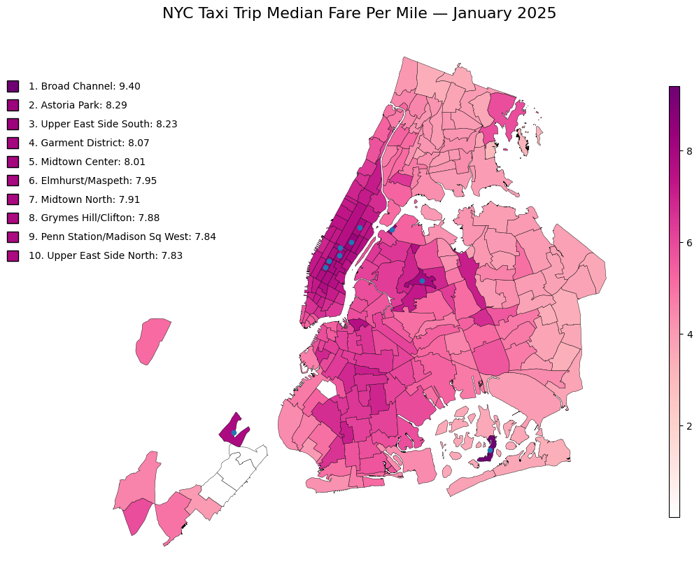

# Sumário

Este estudo analisou as viagens dos táxis amarelos de Nova Iorque em janeiro de 2025, com o objetivo de investigar a distribuição espacial da procura de táxis e determinadas características relacionadas com as tarifas e o congestionamento entre as zonas de táxi de Nova Iorque. A análise combinou limpeza dos dados, análise exploratória, avaliação estatística das variáveis e visualização geoespacial, incluindo a construção de um mapa interativo para a exploração ao nível das zonas.

Os resultados revelaram uma forte concentração da atividade dos táxis em Manhattan, diferenças substanciais nos fluxos de viagens entre os diferentes bairros e uma clara variação espacial na distância das viagens e noutras características relacionadas com a mobilidade. Foram utilizadas medidas estatísticas robustas sempre que distribuições fortemente assimétricas poderiam, de outro modo, distorcer os resultados agregados.

# Sobre o Estudo

O objetivo consiste em investigar de que forma a procura de táxis e as características das viagens variam espacialmente em Nova Iorque. A análise centra-se na procura de viagens, nos fluxos origem–destino, na distância das viagens, na tarifa por milha, na duração por milha, na ocupação por passageiros e nos rácios de sobretaxa de congestionamento.

O estudo inclui a avaliação da qualidade dos dados, o pré-processamento, a análise exploratória dos dados, a engenharia de variáveis, a agregação ao nível das zonas e a visualização geoespacial. Os mapas estáticos são utilizados para identificar padrões espaciais mais abrangentes, enquanto um **[mapa interativo](https://luisritofilipe.github.io/data_science_learning/other/NYC_taxi_trip_interactive_map.html)** permite uma exploração detalhada das zonas de táxi individuais e das suas variáveis agregadas.

# Sobre o Conjunto de Dados

O presente estudo utiliza o conjunto de dados NYC Yellow Taxi Trip Record de janeiro de 2025, em conjunto com a NYC Taxi Zone Lookup Table e o shapefile das zonas de táxi disponibilizados pela NYC Taxi and Limousine Commission (TLC).

Ligação de acesso ao conjunto de dados: https://www.nyc.gov/site/tlc/about/tlc-trip-record-data.page

# Metodologia

- Tratamento e Pré-processamento de Dados
- Análise Exploratória de Dados e Engenharia de Variáveis
- Mapa Geospacial Interativo
- Conclusões

# Tratamento e Pré-processamento de Dados

Os conjuntos de dados utilizados neste estudo são os seguintes:

- "yellow_tripdata_2025-01.parquet", que contém as viagens de táxi amarelo de Nova Iorque registadas em janeiro de 2025 e 20 variáveis relacionadas com as viagens.
- "taxi_zone_lookup.csv", que contém o LocationID, o bairro, a zona e a zona de serviço associados a cada zona de táxi.
- "taxi_zones/taxi_zones.shp", que contém os limites geográficos e os identificadores das zonas de táxi necessários para a análise e representação cartográfica geoespacial.

Os dados das viagens foram combinados com a informação das zonas de táxi utilizando PULocationID e DOLocationID após a limpeza inicial. O shapefile foi posteriormente utilizado para obter a representação geográfica das zonas de táxi. As estatísticas descritivas do conjunto de dados das viagens são apresentadas abaixo.

```
<class 'pandas.core.frame.DataFrame'> RangeIndex: 3475226 entries, 0 to 3475225 Columns: 20 entries, VendorID to cbd_congestion_fee dtypes: datetime64[us](2), float64(13), int32(3), int64(1), object(1) memory usage: 490.5+ MB
```

|  | VendorID | tpep_pickup_datetime | tpep_dropoff_datetime | passenger_count | trip_distance | RatecodeID | store_and_fwd_flag | PULocationID | DOLocationID | payment_type | fare_amount | extra | mta_tax | tip_amount | tolls_amount | improvement_surcharge | total_amount | congestion_surcharge | Airport_fee | cbd_congestion_fee |
| --- | --- | --- | --- | --- | --- | --- | --- | --- | --- | --- | --- | --- | --- | --- | --- | --- | --- | --- | --- | --- |
| count | 3.475226e+06 | 3475226 | 3475226 | 2.935077e+06 | 3.475226e+06 | 2.935077e+06 | 2935077 | 3.475226e+06 | 3.475226e+06 | 3.475226e+06 | 3.475226e+06 | 3.475226e+06 | 3.475226e+06 | 3.475226e+06 | 3.475226e+06 | 3.475226e+06 | 3.475226e+06 | 2.935077e+06 | 2.935077e+06 | 3.475226e+06 |
| unique | NaN | NaN | NaN | NaN | NaN | NaN | 2 | NaN | NaN | NaN | NaN | NaN | NaN | NaN | NaN | NaN | NaN | NaN | NaN | NaN |
| top | NaN | NaN | NaN | NaN | NaN | NaN | N | NaN | NaN | NaN | NaN | NaN | NaN | NaN | NaN | NaN | NaN | NaN | NaN | NaN |
| freq | NaN | NaN | NaN | NaN | NaN | NaN | 2927431 | NaN | NaN | NaN | NaN | NaN | NaN | NaN | NaN | NaN | NaN | NaN | NaN | NaN |
| mean | 1.785428e+00 | 2025-01-17 11:02:55.910964 | 2025-01-17 11:17:56.997901 | 1.297859e+00 | 5.855126e+00 | 2.482535e+00 | NaN | 1.651916e+02 | 1.641252e+02 | 1.036623e+00 | 1.708180e+01 | 1.317737e+00 | 4.780991e-01 | 2.959813e+00 | 4.493081e-01 | 9.547946e-01 | 2.561129e+01 | 2.225237e+00 | 1.239111e-01 | 4.834093e-01 |
| min | 1.000000e+00 | 2024-12-31 20:47:55 | 2024-12-18 07:52:40 | 0.000000e+00 | 0.000000e+00 | 1.000000e+00 | NaN | 1.000000e+00 | 1.000000e+00 | 0.000000e+00 | -9.000000e+02 | -7.500000e+00 | -5.000000e-01 | -8.600000e+01 | -1.269400e+02 | -1.000000e+00 | -9.010000e+02 | -2.500000e+00 | -1.750000e+00 | -7.500000e-01 |
| 25% | 2.000000e+00 | 2025-01-10 07:59:01 | 2025-01-10 08:15:29.500000 | 1.000000e+00 | 9.800000e-01 | 1.000000e+00 | NaN | 1.320000e+02 | 1.130000e+02 | 1.000000e+00 | 8.600000e+00 | 0.000000e+00 | 5.000000e-01 | 0.000000e+00 | 0.000000e+00 | 1.000000e+00 | 1.520000e+01 | 2.500000e+00 | 0.000000e+00 | 0.000000e+00 |
| 50% | 2.000000e+00 | 2025-01-17 15:41:33 | 2025-01-17 15:59:34 | 1.000000e+00 | 1.670000e+00 | 1.000000e+00 | NaN | 1.620000e+02 | 1.620000e+02 | 1.000000e+00 | 1.211000e+01 | 0.000000e+00 | 5.000000e-01 | 2.450000e+00 | 0.000000e+00 | 1.000000e+00 | 1.995000e+01 | 2.500000e+00 | 0.000000e+00 | 7.500000e-01 |
| 75% | 2.000000e+00 | 2025-01-24 19:34:06 | 2025-01-24 19:48:31 | 1.000000e+00 | 3.100000e+00 | 1.000000e+00 | NaN | 2.340000e+02 | 2.340000e+02 | 1.000000e+00 | 1.950000e+01 | 2.500000e+00 | 5.000000e-01 | 3.930000e+00 | 0.000000e+00 | 1.000000e+00 | 2.778000e+01 | 2.500000e+00 | 0.000000e+00 | 7.500000e-01 |
| max | 7.000000e+00 | 2025-02-01 00:00:44 | 2025-02-01 23:44:11 | 9.000000e+00 | 2.764236e+05 | 9.900000e+01 | NaN | 2.650000e+02 | 2.650000e+02 | 5.000000e+00 | 8.633721e+05 | 1.500000e+01 | 1.050000e+01 | 4.000000e+02 | 1.709400e+02 | 1.000000e+00 | 8.633804e+05 | 2.500000e+00 | 6.750000e+00 | 7.500000e-01 |
| std | 4.263282e-01 | NaN | NaN | 7.507503e-01 | 5.646016e+02 | 1.163277e+01 | NaN | 6.452948e+01 | 6.940169e+01 | 7.013334e-01 | 4.634729e+02 | 1.861509e+00 | 1.374623e-01 | 3.779681e+00 | 2.002582e+00 | 2.781938e-01 | 4.636585e+02 | 9.039932e-01 | 4.725090e-01 | 3.619307e-01 |

Uma inspeção inicial do conjunto de dados revelou inconsistências substanciais em várias variáveis, que exigiram tratamento para evitar valores agregados irrealistas ou desproporcionais. Estas inconsistências poderiam distorcer as estatísticas descritivas, as comparações ao nível das zonas e as métricas derivadas, particularmente as que envolvem rácios como a tarifa ou a duração por milha. Foram identificados e removidos 1927 registos com duração de viagem igual a zero.

| Zero Trip Duration | Count |
| --- | --- |
| True | 1927 |

Foram também identificados e removidos registos com durações negativas, extremamente curtas ou invulgarmente longas, tendo estas últimas chegado a vários dias.

|  | count | mean | std | min | 0,1% | 0,5% | 1% | 5% | 50% | 99% | max |
| --- | --- | --- | --- | --- | --- | --- | --- | --- | --- | --- | --- |
| 0 | 3475226.0 | 901.086937 | 2322.814932 | -3088339.0 | 4.0 | 10.0 | 40.0 | 202.0 | 702.0 | 3535.0 | 337579.0 |

Foram identificados e removidos 90 893 registos com distância de viagem igual a zero.

| Zero Trip Distance | Count |
| --- | --- |
| True | 90893 |

Foram identificados e removidos 24 656 registos com número de passageiros igual a zero.

| Zero Passenger Count | Count |
| --- | --- |
| True | 24656 |

Foram identificados e removidos 1398 registos com valor de tarifa igual a zero e um registo com um valor de tarifa superior a 800 000.

| Zero Fare Amount | Count |
| --- | --- |
| True | 1398 |

Foram identificados e removidos 2281 registos com uma velocidade média de viagem irrealista, superior a 70 mph.

| Unrealistic Average Speed | Count |
| --- | --- |
| True | 2281 |

Após a limpeza dos dados, não foram encontrados valores em falta.

# Análise Exploratória de Dados e Engenharia de Variáveis

Após a limpeza dos dados, foi realizada uma análise exploratória para examinar as distribuições e relações entre as principais variáveis relacionadas com as viagens, a distância, a duração e as tarifas. Foi dada particular atenção à identificação de valores atípicos remanescentes, à avaliação da distribuição espacial das viagens entre as zonas de origem e destino e à avaliação das variáveis adequadas para a posterior agregação ao nível das zonas e análise geoespacial.

A informação relativa aos bairros e às zonas do conjunto de dados df_zone foi posteriormente associada aos dados das viagens através dos LocationIDs de origem e destino. Foram identificados valores categóricos adicionais em falta devido a LocationIDs sem informação geográfica válida na tabela de correspondência das zonas. Os LocationIDs 264 e 265 não representam zonas de táxi válidas de Nova Iorque e foram, por isso, excluídos da análise.

A tabela seguinte apresenta o número agregado de origens e destinos por bairro, juntamente com o balanço líquido, calculado como a diferença entre o número de viagens como destino e o número de viagens como origem. Manhattan domina claramente como origem e como destino, mantendo simultaneamente um fluxo líquido relativamente equilibrado, o que evidencia o seu papel enquanto principal origem e destino das viagens de táxi. Por outro lado, Queens apresenta o balanço líquido mais negativo, indicando substancialmente mais viagens como origem nesse bairro do que viagens como destino, enquanto Brooklyn regista o balanço líquido positivo mais elevado, indicando o padrão oposto.

| PU_Borough | Count1 | DO_Borough | Count2 | NetFlow |
| --- | --- | --- | --- | --- |
| Manhattan | 2495628 | Manhattan | 2511978 | 16350 |
| Queens | 220957 | Queens | 109444 | -111513 |
| Brooklyn | 20124 | Brooklyn | 99971 | 79847 |
| Bronx | 4335 | Bronx | 13453 | 9118 |
| Staten Island | 61 | EWR | 5774 | 5713 |
| EWR | 14 | Staten Island | 499 | 485 |

Para examinar mais detalhadamente a distribuição espacial das viagens de táxi, a tabela seguinte apresenta a matriz de fluxos origem-destino agregada por bairro de origem e de destino. As linhas representam o bairro de origem, enquanto as colunas representam o bairro de destino. Os valores na diagonal correspondem às viagens que têm origem e terminam dentro do mesmo bairro, enquanto os valores fora da diagonal representam viagens entre diferentes bairros.

| DO_Borough PU_Borough | Bronx | Brooklyn | EWR | Manhattan | Queens | Staten Island | Total |
| --- | --- | --- | --- | --- | --- | --- | --- |
| Bronx | 1004 | 322 | 1 | 2500 | 508 | 0 | 4335 |
| Brooklyn | 312 | 13186 | 27 | 4668 | 1879 | 52 | 20124 |
| EWR | 0 | 2 | 2 | 8 | 0 | 2 | 14 |
| Manhattan | 7476 | 51124 | 5602 | 2371203 | 60001 | 222 | 2495628 |
| Queens | 4661 | 35299 | 140 | 133591 | 47055 | 211 | 220957 |
| Staten Island | 0 | 38 | 2 | 8 | 1 | 12 | 61 |
| Total | 13453 | 99971 | 5774 | 2511978 | 109444 | 499 | 2741119 |

Na etapa seguinte, as viagens de táxi foram agregadas ao nível das zonas para caracterizar os padrões de viagem em toda a área de estudo. Foram calculados os números de origens e destinos para todas as zonas representadas, juntamente com o respetivo balanço líquido. As variáveis ao nível das viagens foram calculadas de acordo com a zona de origem, tendo em consideração a assimetria das distribuições subjacentes. A mediana da distância das viagens foi utilizada como medida robusta da distância típica percorrida pelas viagens com origem em cada zona. Foi calculada a distância média das viagens acima da mediana para caracterizar a metade superior da distribuição das distâncias. O rácio de sobretaxa de congestionamento foi calculado para identificar as zonas com uma maior proporção de viagens sujeitas à sobretaxa de congestionamento, enquanto a média de passageiros por viagem foi utilizada para avaliar a ocupação típica. A mediana da tarifa por milha foi utilizada como medida robusta da tarifa típica em relação à distância, dada a forte assimetria desta métrica. Por fim, foi calculada a duração média por milha para comparar a duração típica das viagens entre as diferentes zonas de origem.

A tabela seguinte apresenta as 10 principais zonas ordenadas pelo número de destinos, juntamente com as respetivas métricas agregadas.

| Zone | LocationID | Borough | Pickups | Dropoffs | NetFlow | MedDist | AvgAboveMedianDist | CongSurchRate | AvgPassenger | MedianFare_Per_Mile | AvgDuration_Per_Mile |
| --- | --- | --- | --- | --- | --- | --- | --- | --- | --- | --- | --- |
| Upper East Side North | 236 | Manhattan | 135899 | 142571 | 6672 | 1.380000 | 2.763478 | 0.995865 | 1.266190 | 7.831325 | 7.193604 |
| Upper East Side South | 237 | Manhattan | 146052 | 131989 | -14063 | 1.200000 | 2.527239 | 0.998295 | 1.251554 | 8.230088 | 7.687970 |
| Midtown Center | 161 | Manhattan | 145100 | 110638 | -34462 | 1.490000 | 3.387794 | 0.995334 | 1.307450 | 8.009050 | 8.327045 |
| Times Sq/Theatre District | 230 | Manhattan | 105677 | 87210 | -18467 | 1.500000 | 4.507390 | 0.988872 | 1.450760 | 7.697842 | 8.022143 |
| Lincoln Square East | 142 | Manhattan | 96386 | 84048 | -12338 | 1.580000 | 3.070948 | 0.997002 | 1.321146 | 7.222222 | 6.662091 |
| Upper West Side South | 239 | Manhattan | 80490 | 83545 | 3055 | 1.540000 | 3.016145 | 0.997664 | 1.320052 | 7.375566 | 6.480344 |
| Murray Hill | 170 | Manhattan | 78370 | 81564 | 3194 | 1.440000 | 3.338667 | 0.992893 | 1.268457 | 7.761194 | 7.693611 |
| Lenox Hill West | 141 | Manhattan | 68814 | 79108 | 10294 | 1.260000 | 2.735050 | 0.997399 | 1.235504 | 7.760417 | 7.139330 |
| Midtown East | 162 | Manhattan | 103923 | 78734 | -25189 | 1.500000 | 3.402388 | 0.995833 | 1.241313 | 7.810219 | 7.983767 |
| Midtown North | 163 | Manhattan | 83593 | 71627 | -11966 | 1.460000 | 3.530111 | 0.993839 | 1.315589 | 7.908497 | 8.114067 |

Apenas aproximadamente 4,1% das viagens têm a mesma zona de origem e de destino, indicando que a grande maioria das viagens de táxi estabelece ligações entre diferentes zonas.

| Same Zone | Count |
| --- | --- |
| False | 2627849 |
| True | 113270 |

As métricas agregadas ao nível das zonas foram posteriormente representadas geograficamente para examinar a sua distribuição espacial em toda a área de estudo. Os mapas seguintes ilustram os padrões espaciais da procura por táxis, da distância das viagens, da tarifa, da duração e das características relacionadas com o congestionamento entre as zonas de táxi de Nova Iorque.

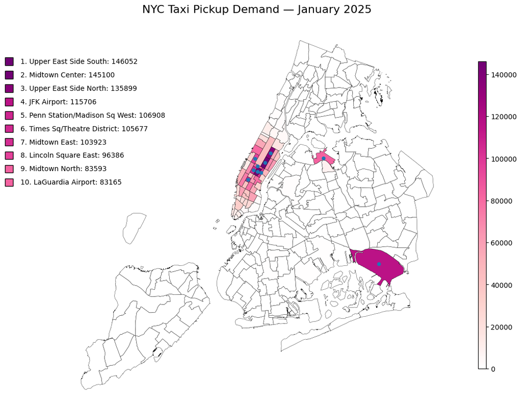

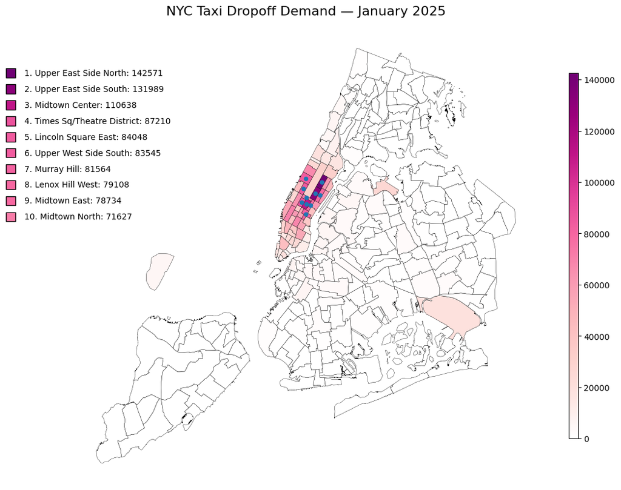

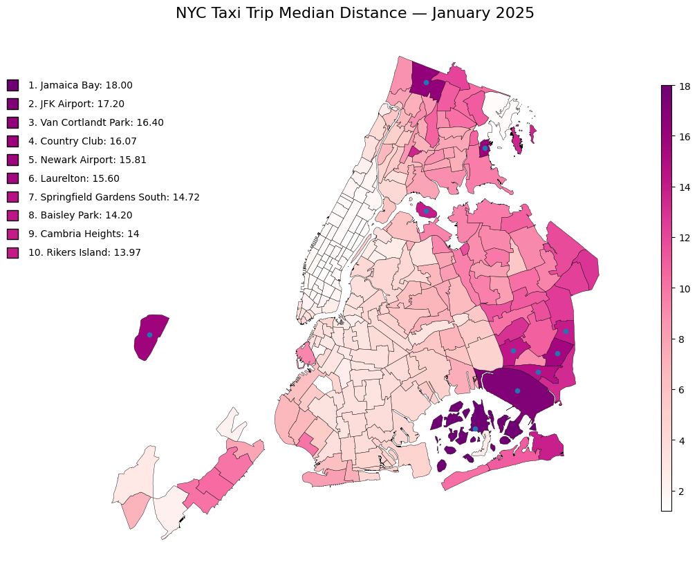

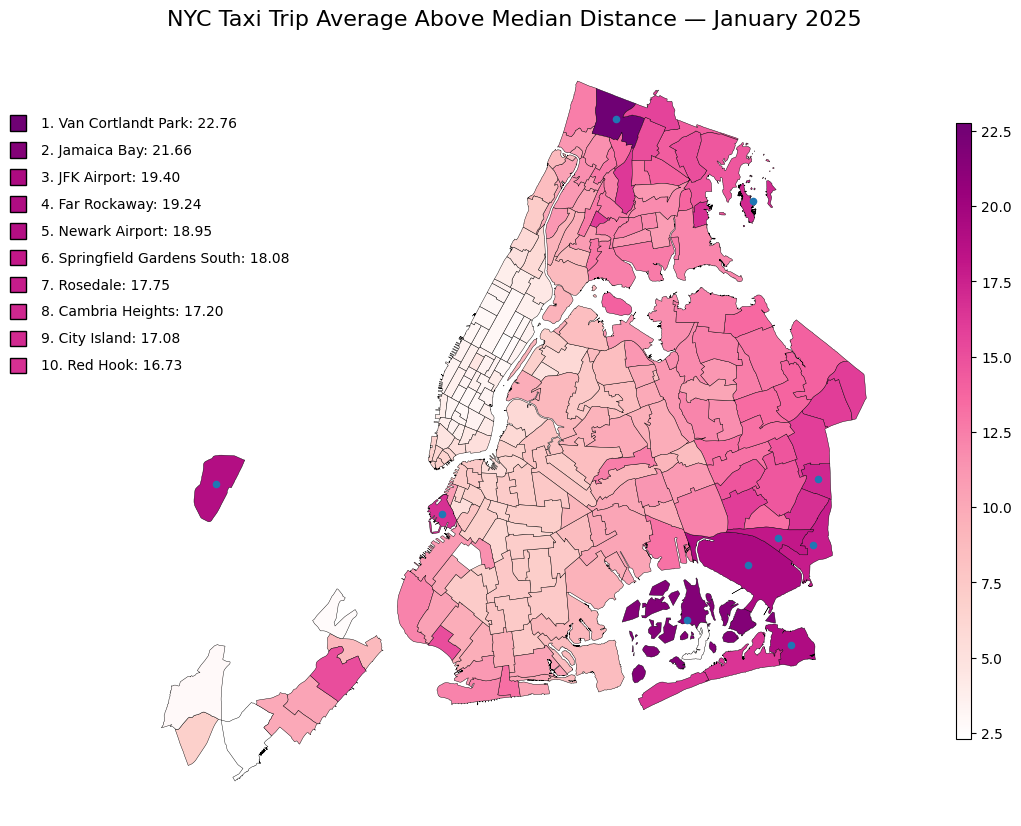

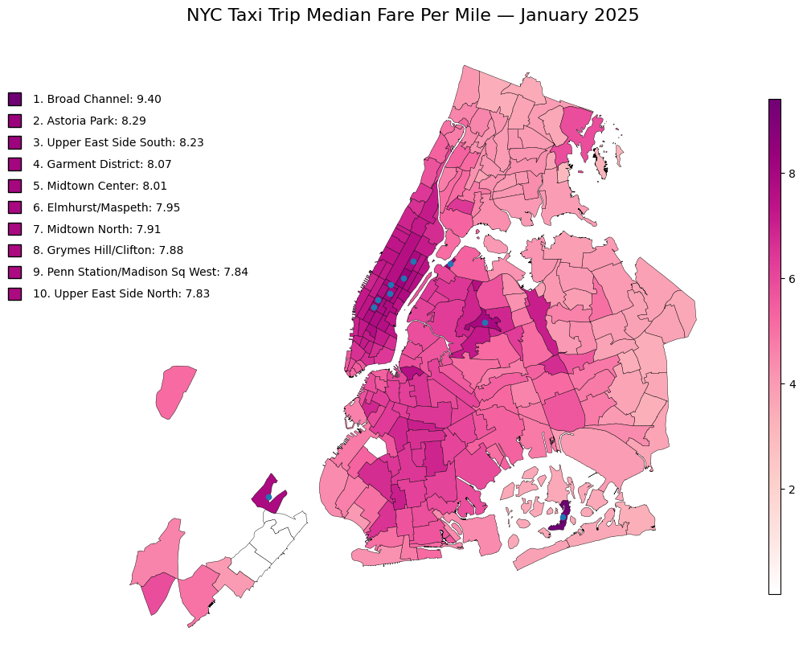

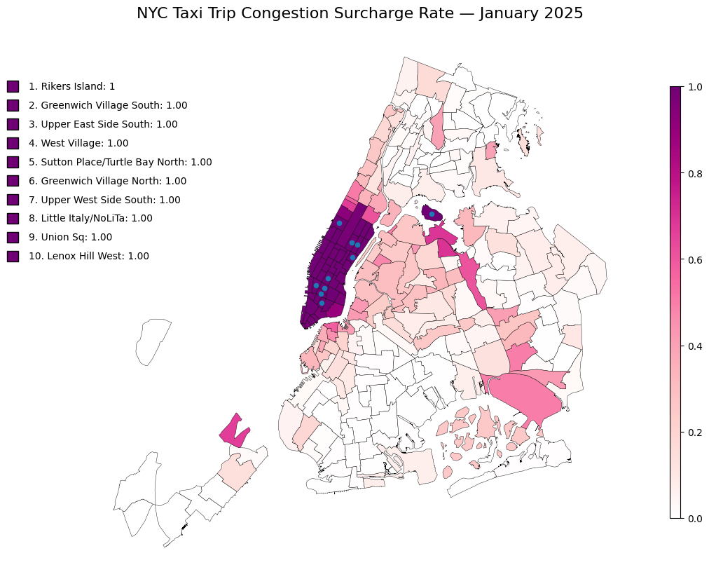

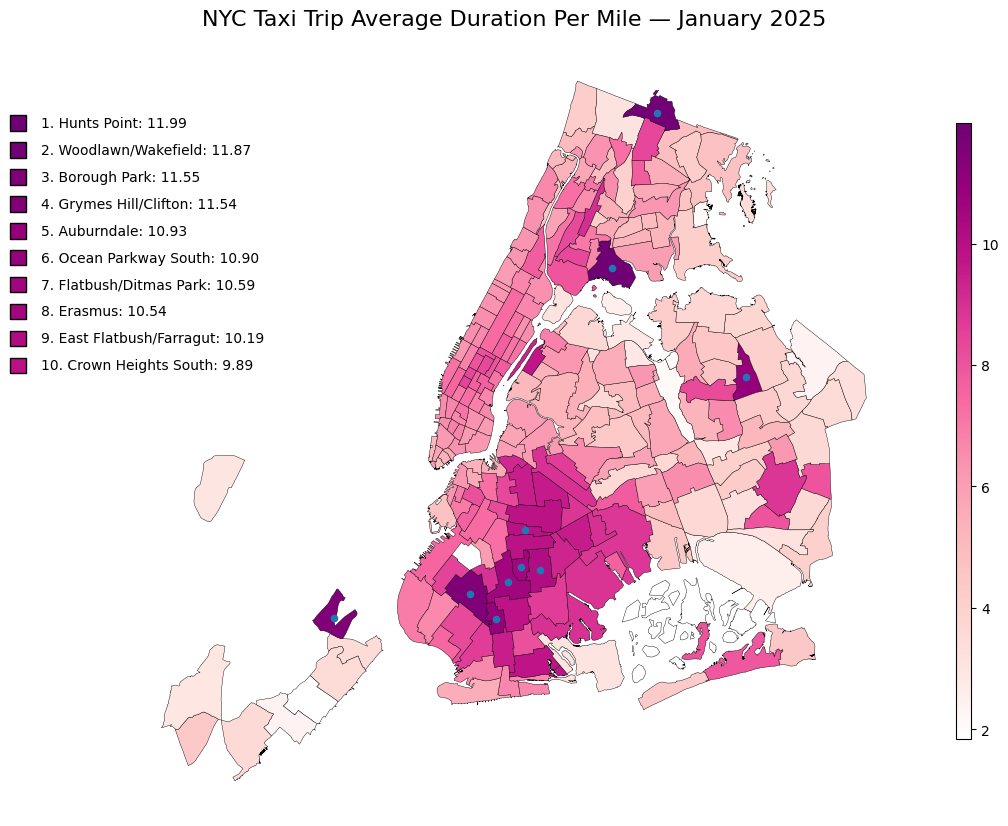

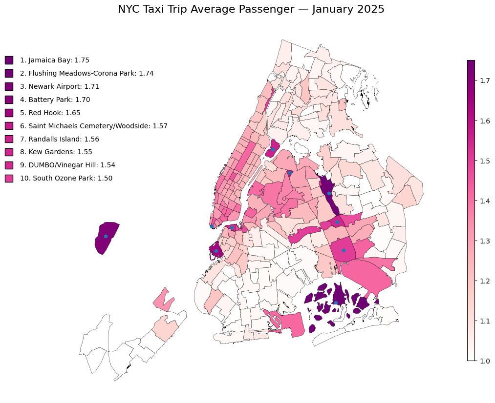

# Mapa Geospacial Interativo

Para complementar as visualizações geoespaciais estáticas, foi desenvolvido um mapa interativo que permite uma exploração detalhada das zonas de táxi individuais. Ao passar o cursor sobre uma zona, são apresentadas as suas principais métricas agregadas, incluindo a procura, a mediana da distância das viagens, a taxa de sobretaxa de congestionamento, o número médio de passageiros, a mediana da tarifa por milha e a duração média por milha. Isto permite examinar interativamente as características ao nível das zonas, mantendo simultaneamente o contexto geográfico geral. Algumas zonas registaram destinos mas nenhuma origem, ou origens mas nenhum destino. Uma vez que as métricas de mobilidade e económicas são calculadas a partir das viagens com origem em cada zona de origem, estas métricas não estão disponíveis para zonas sem origem e são apresentadas como zero no mapa interativo. O mapa interativo pode ser consultado **[aqui](https://luisritofilipe.github.io/data_science_learning/other/NYC_taxi_trip_interactive_map.html)**.

# Conclusões

Este estudo apresentou uma análise geoespacial das viagens de táxi de Nova Iorque em janeiro de 2025, combinando informação ao nível das viagens com os limites das zonas de táxi para caracterizar a procura, os padrões de mobilidade e determinadas características económicas e relacionadas com o congestionamento em toda a área de estudo.

A análise revelou uma forte concentração da atividade dos táxis em Manhattan, que representou a grande maioria das origens e destinos, mantendo simultaneamente um balanço líquido relativamente equilibrado. Os restantes bairros apresentaram padrões de balanço substancialmente diferentes, com Queens a apresentar um balanço fluxo líquido negativo e Brooklyn o balanço líquido positivo mais elevado. A distância das viagens apresentou igualmente um padrão espacial claro, com as zonas mais afastadas de Manhattan geralmente associadas a viagens mais longas.

A análise destacou ainda a importância de um pré-processamento adequado dos dados e da utilização de estatísticas robustas. Várias inconsistências presentes nos registos originais poderiam ter distorcido substancialmente as métricas agregadas, particularmente as medidas baseadas em rácios, como a tarifa e a duração por milha. A forte assimetria observada na distância das viagens e na tarifa por milha motivou a utilização de medidas baseadas na mediana sempre que apropriado.

Por fim, o mapa geoespacial interativo complementa as visualizações estáticas ao permitir explorar com maior detalhe as zonas individuais e as respetivas variáveis agregadas. Em termos gerais, o estudo demonstra como os dados ao nível das viagens podem ser transformados em indicadores espaciais interpretáveis da procura e da mobilidade dos táxis urbanos.